# Analyses

Chase Latour

2023-12-18

# Description

This HTML/Rmd document will contain the analyses for the data generated for the multiple_outcomes_pregnancy R project.

# Describe Cohort

Describe the patient cohort. This will allow us to check for weird data issues.

## Read in the data

```r
# Get the directory where the Rmd file is located
rmd_directory <- dirname(rstudioapi::getSourceEditorContext()$path)

# Specify the Excel file name and path relative to the Rmd file location
data_read <- file.path(rmd_directory, "data.rds")

dataset <- readRDS(data, file = data_read)
```

## Identify the cohort that entered the trial.

```r
trial <- dataset %>%
  subset(trial_participant == TRUE) %>%
  # Identify the observed outcomes
  mutate(preg_outcome_final = ifelse(trt == 1,
                                     preg_outcome_final_trt,
                                     preg_outcome_final_untrt),
         preg_outcome_final_gw = ifelse(trt == 1,
                                        preg_outcome_final_gw_trt,
                                        preg_outcome_final_gw_untrt),
         preeclampsia = ifelse(trt == 1,
                               preeclampsia_trt,
                               preeclampsia_untrt),
         sga = ifelse(trt == 1,
                      sga_trt,
                      sga_untrt)) %>%
  rowwise() %>%
  mutate(censor = ifelse(first_censoring_gw < preg_outcome_final_gw & !is.na(first_censoring_gw),
                    1,
                    0),
         time = ifelse(censor == 1,
                       first_censoring_gw,
                       preg_outcome_final_gw)
         ) %>%
  ungroup()

# Note that censoring is the same regardless of treatment.
```

## Number of trial participants

### Total

```r
trial %>%
  summarize(count = n())
```

```
## # A tibble: 1 × 1
##   count
##   <int>
## 1  5175
```

### Across treatment groups

```r
# Approx half and half, as expected
trial %>%
  group_by(trt) %>%
  summarize(count = n(),
            percent = round(count / nrow(trial) * 100),2)
```

```
## # A tibble: 2 × 4
##     trt count percent   `2`
##   <int> <int>   <dbl> <dbl>
## 1     0  2593      50     2
## 2     1  2582      50     2
```

### Timing of indexing into the cohort

Quantitative description of the distribution of gestational age at trial indices, by treatment group.

```r
trial %>%
  group_by(trt) %>%
  summarize(
            min = min(first_index),
            p25 = quantile(first_index, 0.25),
            median = median(first_index),
            p75 = quantile (first_index, 0.75),
            max = max(first_index),
            nmiss = sum(is.na(first_index))
            )
```

```
## # A tibble: 2 × 7
##     trt   min   p25 median   p75   max nmiss
##   <int> <dbl> <dbl>  <dbl> <dbl> <dbl> <int>
## 1     0     2     3      4     6    16     0
## 2     1     2     3      4     6    14     0
```

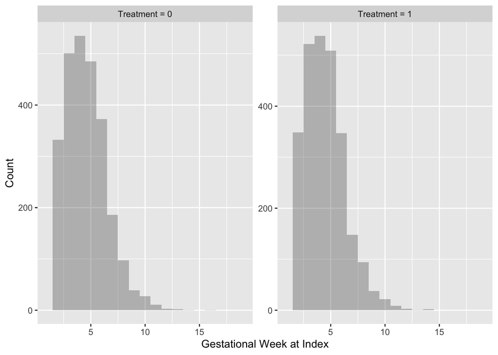

```r
trial %>%
  #mutate(trt_label = factor(trt)) %>%
  mutate(trt_label = factor(trt, labels = c("Treatment = 0", "Treatment = 1"))) %>%
  ggplot(aes(x = first_index)) +
  geom_histogram(alpha=0.35, position = 'identity', binwidth = 1) +
  facet_wrap(~trt_label, scales = "free") +
  #ylim(0, 200) +  # Set the y-axis limit to 0 to 200
  xlim(1, 19) +
  xlab("Gestational Week at Index") +  # Set the x-axis label
  ylab("Count")
```

## Number of live births and fetal deaths across treatment groups

Currently, these counts ignore censoring events.

```r
trial %>%
  group_by(trt) %>%
  summarize(fetal_death = sum(preg_outcome_final == 'fetaldeath'),
            fd_percent = round(fetal_death / n() * 100,1),
            livebirth = sum(preg_outcome_final == 'livebirth'),
            lb_percent = round(livebirth / n() * 100,1))
```

```
## # A tibble: 2 × 5
##     trt fetal_death fd_percent livebirth lb_percent
##   <int>       <int>      <dbl>     <int>      <dbl>
## 1     0         863       33.3      1730       66.7
## 2     1         771       29.9      1811       70.1
```

## Distribution of pregnancy outcomes

Quantitative description of the distribution of pregnancy outcomes, by treatment group.

Currently, these counts ignore censoring events.

```r
trial %>%
  group_by(trt, preg_outcome_final) %>%
  summarize(
            min = min(preg_outcome_final_gw),
            p25 = quantile(preg_outcome_final_gw, 0.25),
            median = median(preg_outcome_final_gw),
            p75 = quantile (preg_outcome_final_gw, 0.75),
            max = max(preg_outcome_final_gw),
            .groups = 'keep'
            )
```

```
## # A tibble: 4 × 7
## # Groups:   trt, preg_outcome_final [4]
##     trt preg_outcome_final   min   p25 median   p75   max
##   <int> <chr>              <int> <dbl>  <dbl> <dbl> <int>
## 1     0 fetaldeath             3     6      9    12    38
## 2     0 livebirth             25    34     36    38    41
## 3     1 fetaldeath             3     6      9    12    37
## 4     1 livebirth             25    35     37    38    41
```

Figural description of the distribution of pregnancy outcomes, facet wrapped by treatment group.

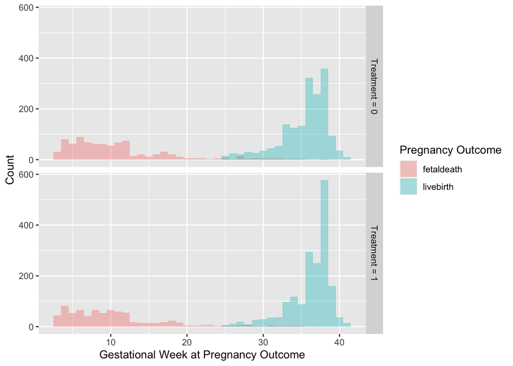

```r
trial %>%
  mutate(trt_label = factor(trt, labels = c("Treatment = 0", "Treatment = 1"))) %>%
  #mutate(trt_label = factor(trt)) %>%
  ggplot(aes(x = preg_outcome_final_gw, fill = preg_outcome_final)) +
  geom_histogram(alpha=0.35, position = 'identity', binwidth = 1) +
  facet_grid(facets = trt_label ~.) +
  xlab("Gestational Week at Pregnancy Outcome") +
  ylab("Count") +
  labs(fill = "Pregnancy Outcome")
```

## Number with preeclampsia and SGA

By treatment group.

Currently, these counts ignore censoring events.

```r
trial %>%
  group_by(trt) %>%
  summarize(preeclampsia = sum(preeclampsia == 1),
            preec_perc = round(preeclampsia / n() * 100, 1),
            sga = sum(sga == 1),
            sga_perc = round(sga / n() * 100, 1))
```

```
## # A tibble: 2 × 5
##     trt preeclampsia preec_perc   sga sga_perc
##   <int>        <int>      <dbl> <int>    <dbl>
## 1     0           58        2.2   189      7.3
## 2     1           43        1.7   174      6.7
```

# Conduct Analyses

## Write Functions

### KM Estimator

Code for function that uses the Kaplan-Meier estimator to estimate risk.

```r
km_estimator <- function(dataset, outcome_var, outcome_var_t){

  ## Run the KM analysis only considering the composite outcome.
  km <- survfit(Surv(get(outcome_var_t), get(outcome_var)) ~ trt, data = dataset)
  # Test: km <- survfit(Surv(preterm_t, preterm_km) ~ trt, data = trial2)
  #summary(km)

  wrisk <- data.frame(t = km$time, s = km$surv, r = 1 - km$surv, se = km$std.err,
                          trt = c(rep(0, km$strata["trt=0"]), rep(1, km$strata["trt=1"])))

  return(wrisk)

}
```

Code for function that plots the KM curve.

```r
km_plot <- function(dataset, plot_title){
  riskplot <- ggplot() +
    geom_step(data = dataset, aes(x = t, y = r,  group = factor(trt), color = factor(trt)))+
    xlab("Weeks from Index")+
    ylab("Risk") +
    scale_color_discrete(labels = c("Untreated", "Treated"))+
    ggtitle(plot_title) +  # Add the title parameter
   # scale_y_continuous(limits = c(0, 0.55), breaks = c(0, 0.1, 0.2, 0.3, 0.4, 0.5))+
    #scale_x_continuous(limits = c(2, 12), breaks = c(0, 2, 4, 6, 8,10, 12))+
    theme_classic(base_size = 15)+
    theme(legend.position = c(0.28, 0.9), legend.title = element_blank(),
          legend.background = element_rect(fill="transparent"),
          panel.background = element_rect(fill = NA),
          panel.grid.major = element_line(colour = "gray", linetype = "dotted"))

  return(riskplot)
}
```

Code for function to get the Risk Ratio at different points in follow-up.

```r
# Function to get the risk ratio with the corresponding confidence interval
km_rr_wCI <- function(data, t_val){

  estimate <- data %>%
    filter(t < t_val+0.5) %>% # Deal with no additional risk scenarios
    group_by(trt) %>%
    summarize(r = last(r),
              se = last(se),
              .groups = 'drop') %>%
    # filter(t == t_val) %>%
    # select(r, se, trt) %>%
    pivot_wider(names_from = trt,
                values_from = c(r, se),
                names_glue = "{.value}_{trt}") %>%
    rowwise() %>%
    mutate(rr = r_1/r_0,
           rd = r_1 - r_0,
           # use delta method to get 95% CI
           logRR = log(rr),
           var_1 = se_1^2,
           var_0 = se_0^2,
           var_logRR = (1/r_0)^2 * var_0 + (1/r_1)^2 * var_1,
           logRR_lower = logRR - 1.96*sqrt(var_logRR),
           logRR_upper = logRR + 1.96*sqrt(var_logRR),
           RR_lower = exp(logRR_lower),
           RR_upper = exp(logRR_upper),
           se_rd = sqrt(se_1^2 + se_0^2),
           RD_lower = rd - 1.96*se_rd,
           RD_upper = rd + 1.96*se_rd,
           Estimator = "Kaplan-Meier") %>%
    select(Estimator, r_0, r_1, rr, RR_lower, RR_upper, rd, RD_lower, RD_upper)
    # mutate(rr = r_1 / r_0,
    #        selnrr = sqrt((1/r_0)^2 * se_0^2 + (1/r_1)^2*se_1^2),
    #        lcl = exp(log(rr) - 1.96*selnrr),
    #        ucl = exp(log(rr) + 1.96*selnrr)) %>%
    # select(r_0, r_1, rr, lcl, ucl)

  return(estimate)

}
```

### AJ Estimator

Code for function that generates the AJ estimator object.

```r
aj_estimator <- function(dataset, outcome_var, outcome_var_t){

  #jitter ties
  #set.seed(1234)
  # Not sure if should set seed for jittering outcomes
  dataset2 <- dataset %>%
    group_by(get(outcome_var_t)) %>%
    add_tally() %>%
    ungroup() %>%
    mutate(
      # Jitter event times
      jitter = runif(nrow(trial2), min = -.01, max = .01), # N in the samp
      time = ifelse(n>1, get(outcome_var_t) + jitter, get(outcome_var_t))
      )

  # Run the AJ model
  aj <- survfit(Surv(time, factor(get(outcome_var))) ~ trt, data = dataset2)

}

#test <- aj_estimator(trial2, "composite_multi", "composite_multi_gw")
```

Code for function that generates RRs from the AJ estimator.

```r
#ASK JESS ABOUT t_val specification

aj_rr <- function(aj_object, t_val){

  mod <- summary(aj_object)

  summod <- data.frame(t = mod$time,
                       r = mod$pstate[,2],
                       se = mod$std.err[,2],
                       # This is not right yet
                       #trt = c(rep(0, mod$strata["trt=0"]), rep(1, mod$strata["trt=1"]))
                       trt = c(rep(0, length(mod[["strata"]][mod[["strata"]] == "trt=0"])),
                                   rep(1, length(mod[["strata"]][mod[["strata"]] == "trt=1"])))
                       ) %>%
    filter(t < t_val+0.5) %>%  # Deal with the jittering of outcomes
    group_by(trt) %>%
    summarize(r = last(r),
              se = last(se),
              .groups = 'drop') %>%
    select(r,se,trt) %>%
      pivot_wider(names_from = trt,
                  values_from = c(r, se),
                  names_glue = "{.value}_{trt}") %>%
      rowwise() %>%
      mutate(rr = r_1/r_0,
           rd = r_1 - r_0,
           # use delta method to get 95% CI
           logRR = log(rr),
           var_1 = se_1^2,
           var_0 = se_0^2,
           var_logRR = (1/r_0)^2 * var_0 + (1/r_1)^2 * var_1,
           logRR_lower = logRR - 1.96*sqrt(var_logRR),
           logRR_upper = logRR + 1.96*sqrt(var_logRR),
           RR_lower = exp(logRR_lower),
           RR_upper = exp(logRR_upper),
           se_rd = sqrt(se_1^2 + se_0^2),
           RD_lower = rd - 1.96*se_rd,
           RD_upper = rd + 1.96*se_rd,
           Estimator = "Aalen-Johansen") %>%
    select(Estimator, r_0, r_1, rr, RR_lower, RR_upper, rd, RD_lower, RD_upper)

  return(summod)

}

# aj_rr(test)
```

Code for function that plots the AJ object. **This still needs some work to be sure that it’s outputting everything correctly.** Currently, the x-axis is wrong. Should be from index date.

```r
aj_plot <- function(aj_object, xlab="Gestational weeks post-conception", ylab="Probability in State",
                    outcome = "", competing = ""){
  plot(aj_object, col=c(1,2,1,2), lty=c(2,2,1,1),
       mark.time=FALSE, lwd=2,  #xscale=12,
       xlab=xlab, ylab=ylab)
  legend("topleft", legend = c(paste(competing, ":untreated"), paste(competing, ":treated"),
                               paste(outcome, ":untreated"), paste(outcome, ":treated")
                               ),
         col = c(1, 2, 1, 2), lty = c(1, 1, 2, 2), lwd = 2, bty = 'n')

  # legend(240, .6, c(paste(outcome, ":untreated"), paste(outcome, ":treated"), paste(competing, ":untreated"), paste(competing, ":treated")),
  #        col = c(1, 2, 1, 2), lty = c(1, 1, 2, 2), lwd = 2, bty = 'n')

}

#aj_plot(test, outcome = "Composite", competing = "Delivery")


## VERY HELPFUL: https://cran.r-project.org/web/packages/survival/vignettes/compete.pdf

## Plotting AJ estimators:
#https://search.r-project.org/CRAN/refmans/Epi/html/plotCIF.html

## More AJ R code:
#https://cran.r-project.org/web/packages/AalenJohansen/index.html
```

## Summarize Bias

Code for function that summarizes the bias between KM and AJ estimators.

```r
compare <- function(km, aj){

  # Calculate the differences
  differences <- tibble(
      # Absolute Risks
      r_0 = km$r_0 - aj$r_0,
      r_1 = km$r_1 - aj$r_1,
      # Risk Ratios
      rr = log(km$rr) - log(aj$rr),
      RR_lower = log(km$RR_lower) - log(aj$RR_lower),
      RR_upper = log(km$RR_upper) - log(aj$RR_upper),
      # Risk differences
      rd = km$rd - aj_rrs_composite$rd,
      RD_lower = km$RD_lower - aj$RD_lower,
      RD_upper = km$RD_upper - aj$RD_upper,
      Estimator = "Differences: KM-AJ"
  )

  # Make the kable object
  kable_object <- rbind(km, aj) %>%
    rbind(differences) %>%
    ungroup() %>%
    mutate(r_0 = round(r_0, 2),
           r_1 = round(r_1, 2),
           rr = round(rr, 2),
           RR_lower = round(RR_lower, 2),
           RR_upper = round(RR_upper, 2),
           rd = round(rd, 2),
           RD_lower = round(RD_lower, 2),
           RD_upper = round(RD_upper, 2)) %>%
    #kbl() %>%
    kable(col.names = c("Estimator", "Risk Among Untreated", "Risk Among Treated","RR", "RR 95% LCL",
                        "RR 95% UCL", "RD", "RD 95% LCL", "RD 95% UCL"),
          align = "lcccccccc") %>%
    kable_classic() %>%
    row_spec(3, bold = T, color = "white", background = "black")

  return(kable_object)

}
```

## Composite Preeclampsia and Fetal Death

### KM Estimator

Output the cumulative incidence curves at the end of follow-up.

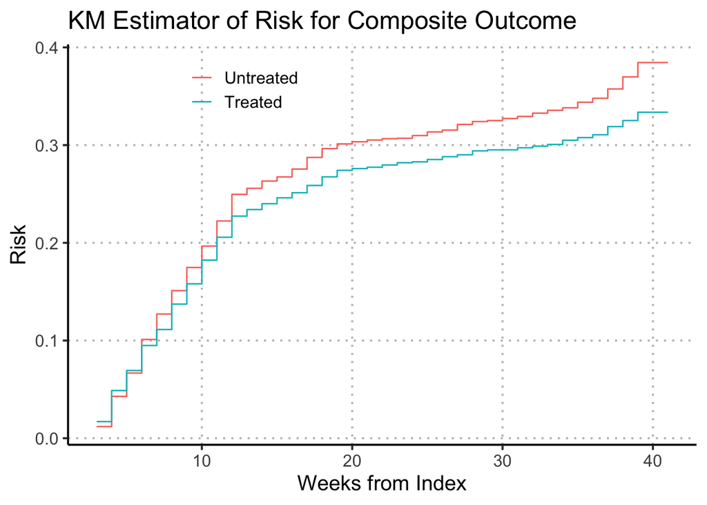

```r
## Create the composite outcome
trial2 <- trial %>%
  mutate(
    # Make an indicator that the patient was censored before we observed their outcome - made earlier
    # censor = ifelse(first_censoring_gw < preg_outcome_final_gw & !is.na(first_censoring_gw),
    #                 1,
    #                 0),
    # Make composite
    composite = case_when(censor == 1 ~ 0,
                          preg_outcome_final == "fetaldeath" & censor == 0 ~ 1,
                          preg_outcome_final == "livebirth" & censor == 0 & preeclampsia == 1 ~ 1,
                          preg_outcome_final == "livebirth" & censor == 0 & preeclampsia == 0 ~ 0) #,
    # composite = ifelse(preg_outcome_final == "fetaldeath" | preeclampsia == 1 & censor == 0,
    #                         1,
    #                         0),
    # composite_gw = ifelse(censor == 0,
    #                       preg_outcome_final_gw,
    #                       first_censoring_gw)
    )

## Run the KM analysis only considering the composite outcome.
#wrisk <- km_estimator(trial2, "composite","composite_gw")
wrisk <- km_estimator(trial2, "composite","time")

riskplot <- km_plot(wrisk, "KM Estimator of Risk for Composite Outcome")

riskplot
```

```r
#ggsave(riskplot, file = "q13.png", width = 5, heigh = 5, units = "cm")
```

Output the risk ratio at the end of follow-up.

```r
#############################################################################################
## Calculate the RR at different weeks of follow-up; SE is infinity at 42 weeks of follow-up
## -- ASK JESS about this.
## -- Funky thing: The standard errors get substantially larger as the weeks progress.
## -- Likely because there are fewer and fewer individuals at risk at 42 weeks and imputing
## -- more censoring.
## -- Need to check this intuition with Jess.

km_rr <- km_rr_wCI(wrisk, 41)
```

### AJ Estimator

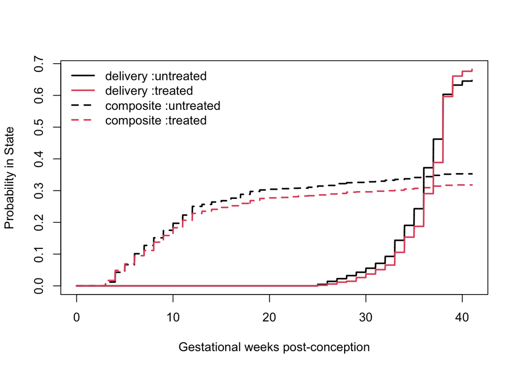

```r
## Make dataset the way that we want it
trial2 <- trial %>%
  mutate(
    # Make an indicator that the patient was censored before we observed their outcome
    # censor = ifelse(first_censoring_gw < preg_outcome_final_gw & !is.na(first_censoring_gw),
    #                 1,
    #                 0),
    # Make a multi-level outcome
    composite_multi = case_when(censor == 1 ~ 0,
                                censor == 0 & preg_outcome_final == "fetaldeath" ~ 1,
                                censor == 0 & preeclampsia == 1 ~ 1,
                                censor == 0 & preg_outcome_final == "livebirth" & preeclampsia == 0 ~ 2
                                ),
    # Make a gestational week variable for the composite_multi variable
    composite_multi_gw = ifelse(censor == 1,
                                first_censoring_gw,
                                preg_outcome_final_gw)
  )


## Run the competing events analysis

# Make the AJ object

aj <- aj_estimator(trial2, "composite_multi", "composite_multi_gw")

# Calculate the RRs

aj_rrs_composite <- aj_rr(aj, 42)

# aj_rrs_composite

# Print the plot

aj_plot(aj_object = aj, outcome = "composite", competing = "delivery")
```

### Estimate the bias between KM and RR

```r
compare(km_rr, aj_rrs_composite)
```

| Estimator | Risk Among Untreated | Risk Among Treated | RR | RR 95% LCL | RR 95% UCL | RD | RD 95% LCL | RD 95% UCL |
| --- | --- | --- | --- | --- | --- | --- | --- | --- |
| Kaplan-Meier | 0.38 | 0.33 | 0.87 | 0.74 | 1.02 | -0.05 | -0.11 | 0.01 |
| Aalen-Johansen | 0.35 | 0.32 | 0.90 | 0.83 | 0.98 | -0.03 | -0.06 | -0.01 |
| Differences: KM-AJ | 0.03 | 0.02 | -0.04 | -0.12 | 0.04 | -0.02 | -0.05 | 0.02 |

### Estimate risks without censoring

```r
trial3 <- trial %>%
  mutate(composite = case_when(preg_outcome_final == "fetaldeath" ~ 1,
                               preg_outcome_final == "livebirth" & preeclampsia == 1 ~ 1,
                               preg_outcome_final == "livebirth" & preeclampsia == 0 ~ 0))

trial3 %>%
  group_by(trt) %>%
  summarize(risk = sum(composite == 1) / n()) %>%
  pivot_wider(names_from = trt,
              values_from = c(risk),
              names_glue = "{.value}_{trt}") %>%
  rowwise() %>%
  mutate(rr = risk_1 / risk_0,
         rd = risk_1 - risk_0) %>%
  kable() %>%
  kable_classic()
```

| risk_0 | risk_1 | rr | rd |
| --- | --- | --- | --- |
| 0.355187 | 0.3152595 | 0.8875872 | -0.0399276 |

## SGA with Fetal Death Only as Competing Event

### KM Estimator

Output the cumulative incidence curves at the end of follow-up.

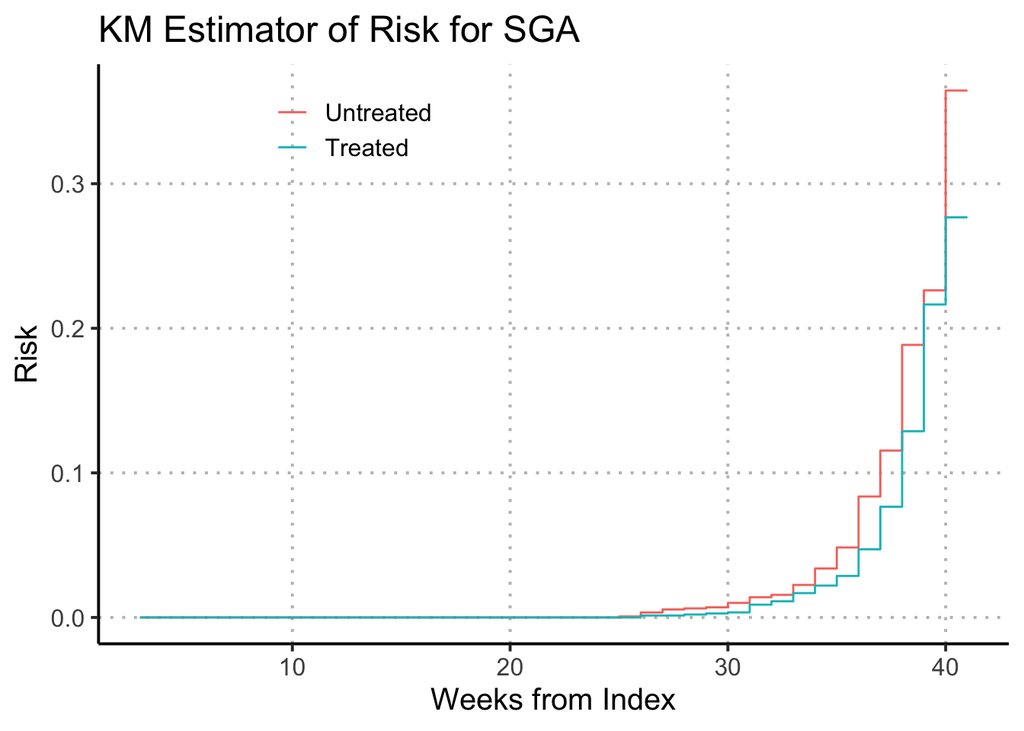

```r
## Create the composite outcome
trial2 <- trial %>%
  mutate(
    # Make an indicator that the patient was censored before we observed their outcome
    # censor = ifelse(first_censoring_gw < preg_outcome_final_gw & !is.na(first_censoring_gw),
    #                 1,
    #                 0),
    # Make an indicator for sga, incorporating censoring
    sga_km = ifelse(sga == 1 & censor == 0,
                    1,
                    0)#,
    # Make a time variable for sga, incorporating censoring
    # sga_t = ifelse(sga == 1 & censor == 0,
    #                preg_outcome_final_gw,
    #                first_censoring_gw)
    )

## Run the KM analysis only considering the composite outcome.
wrisk <- km_estimator(trial2, "sga_km","time")

riskplot <- km_plot(wrisk, "KM Estimator of Risk for SGA")

riskplot
```

```r
#ggsave(riskplot, file = "q13.png", width = 5, height = 5, units = "cm")
```

Output the risk ratio at the end of follow-up.

```r
# Undefined at 42 weeks
km_rr <- km_rr_wCI(wrisk, 42)

# km_rr42
```

### AJ Estimator

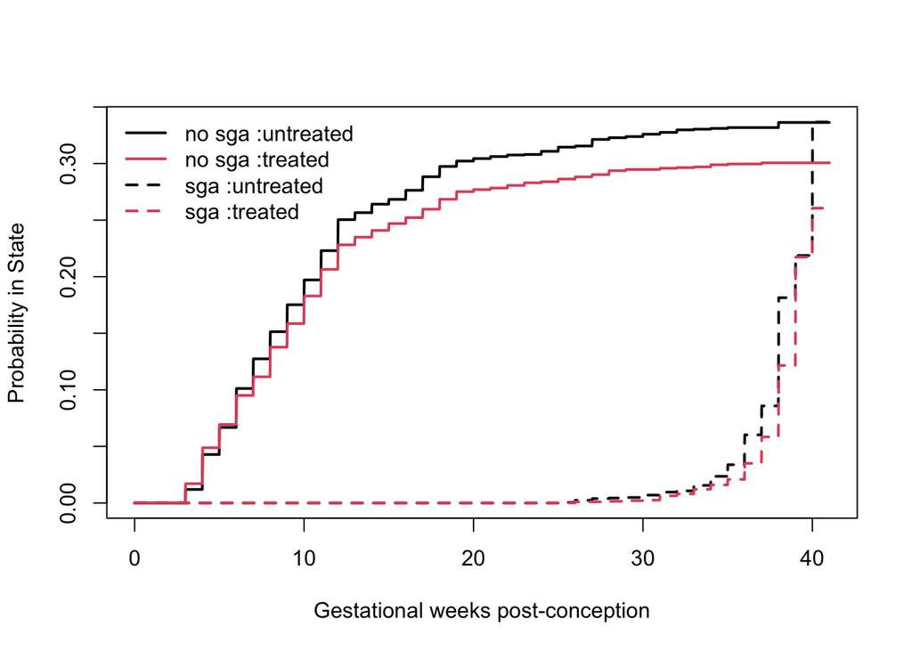

```r
## Make dataset the way that we want it
trial2 <- trial %>%
  mutate(
    # Make an indicator that the patient was censored before we observed their outcome
    censor = ifelse(first_censoring_gw < preg_outcome_final_gw & !is.na(first_censoring_gw),
                    1,
                    0),
    # Make a multi-level outcome
    sga_multi = case_when(censor == 1 ~ 0,
                          censor == 0 & sga == 1 ~ 1,
                          censor == 0 & preg_outcome_final == "fetaldeath" ~ 2,
                          censor == 0 & sga == 0 & preg_outcome_final == "livebirth" ~ 0),
    # COULD BE 3 - COME BACK
    # Make a gestational week variable for the sga_multi variable
    sga_multi_gw = ifelse(censor == 1,
                                first_censoring_gw,
                                preg_outcome_final_gw)
  )


## Run the competing events analysis

# Make the AJ object

aj <- aj_estimator(trial2, "sga_multi", "sga_multi_gw")

# Calculate the RRs

aj_rrs_composite <- aj_rr(aj, 42)

# aj_rrs_composite

# Print the plot

aj_plot(aj_object = aj, outcome = "sga", competing = "no sga")
```

### Estimate the bias between KM and RR

```r
compare(km_rr, aj_rrs_composite)
```

| Estimator | Risk Among Untreated | Risk Among Treated | RR | RR 95% LCL | RR 95% UCL | RD | RD 95% LCL | RD 95% UCL |
| --- | --- | --- | --- | --- | --- | --- | --- | --- |
| Kaplan-Meier | 0.36 | 0.28 | 0.76 | 0.40 | 1.44 | -0.09 | -0.3 | 0.12 |
| Aalen-Johansen | 0.34 | 0.26 | 0.77 | 0.52 | 1.15 | -0.08 | -0.2 | 0.05 |
| Differences: KM-AJ | 0.03 | 0.02 | -0.02 | -0.26 | 0.22 | -0.01 | -0.1 | 0.08 |

### Estimate without censoring

```r
trial3 <- trial %>%
  mutate(sga_out = ifelse(sga == 1, 1, 0))

trial3 %>%
  group_by(trt) %>%
  summarize(risk = sum(sga_out == 1) / n()) %>%
  pivot_wider(names_from = trt,
              values_from = c(risk),
              names_glue = "{.value}_{trt}") %>%
  rowwise() %>%
  mutate(rr = risk_1 / risk_0,
         rd = risk_1 - risk_0) %>%
  kable() %>%
  kable_classic()
```

| risk_0 | risk_1 | rr | rd |
| --- | --- | --- | --- |
| 0.0728885 | 0.0673896 | 0.9245571 | -0.0054989 |

## SGA with all Competing Events

### KM Estimator

Output the cumulative incidence curves at the end of follow-up.

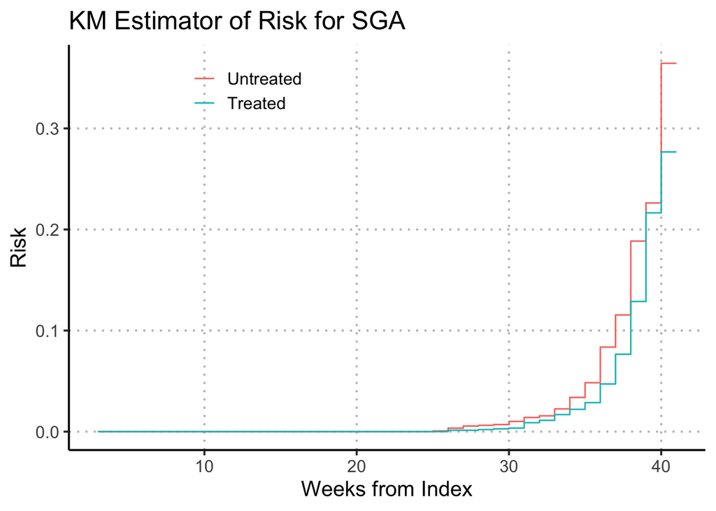

```r
## Create the composite outcome
trial2 <- trial %>%
  mutate(
    # Make an indicator that the patient was censored before we observed their outcome
    # censor = ifelse(first_censoring_gw < preg_outcome_final_gw & !is.na(first_censoring_gw),
    #                 1,
    #                 0),
    # Make an indicator for sga, incorporating censoring
    sga_km = ifelse(sga == 1 & censor == 0,
                    1,
                    0)#,
    # Make a time variable for sga, incorporating censoring
    # sga_t = ifelse(sga == 1 & censor == 0,
    #                preg_outcome_final_gw,
    #                first_censoring_gw)
    )

## Run the KM analysis only considering the composite outcome.
wrisk <- km_estimator(trial2, "sga_km","time")

riskplot <- km_plot(wrisk, "KM Estimator of Risk for SGA")

riskplot
```

```r
#ggsave(riskplot, file = "q13.png", width = 5, height = 5, units = "cm")
```

Output the risk ratio at the end of follow-up.

```r
# Undefined at 42 weeks
km_rr <- km_rr_wCI(wrisk, 42)

# km_rr42
```

### AJ Estimator

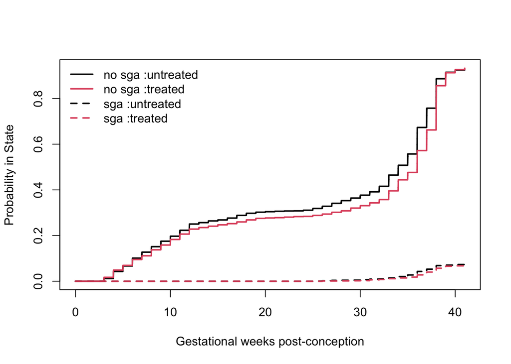

```r
## Make dataset the way that we want it
trial2 <- trial %>%
  mutate(
    # Make an indicator that the patient was censored before we observed their outcome
    censor = ifelse(first_censoring_gw < preg_outcome_final_gw & !is.na(first_censoring_gw),
                    1,
                    0),
    # Make a multi-level outcome
    sga_multi = case_when(censor == 1 ~ 0,
                          censor == 0 & sga == 1 ~ 1,
                          censor == 0 & preg_outcome_final == "fetaldeath" ~ 2,
                          censor == 0 & sga == 0 & preg_outcome_final == "livebirth" ~ 2),
    # COULD BE 3 - COME BACK
    # Make a gestational week variable for the sga_multi variable
    sga_multi_gw = ifelse(censor == 1,
                                first_censoring_gw,
                                preg_outcome_final_gw)
  )


## Run the competing events analysis

# Make the AJ object

aj <- aj_estimator(trial2, "sga_multi", "sga_multi_gw")

# Calculate the RRs

aj_rrs_composite <- aj_rr(aj, 42)

# aj_rrs_composite

# Print the plot

aj_plot(aj_object = aj, outcome = "sga", competing = "no sga")
```

### Estimate the bias between KM and RR

```r
compare(km_rr, aj_rrs_composite)
```

| Estimator | Risk Among Untreated | Risk Among Treated | RR | RR 95% LCL | RR 95% UCL | RD | RD 95% LCL | RD 95% UCL |
| --- | --- | --- | --- | --- | --- | --- | --- | --- |
| Kaplan-Meier | 0.36 | 0.28 | 0.76 | 0.40 | 1.44 | -0.09 | -0.30 | 0.12 |
| Aalen-Johansen | 0.07 | 0.07 | 0.92 | 0.73 | 1.16 | -0.01 | -0.02 | 0.01 |
| Differences: KM-AJ | 0.29 | 0.21 | -0.19 | -0.60 | 0.21 | -0.08 | -0.28 | 0.11 |

### Estimate without censoring

```r
trial3 <- trial %>%
  mutate(sga_out = ifelse(sga == 1, 1, 0))

trial3 %>%
  group_by(trt) %>%
  summarize(risk = sum(sga_out == 1) / n()) %>%
  pivot_wider(names_from = trt,
              values_from = c(risk),
              names_glue = "{.value}_{trt}") %>%
  rowwise() %>%
  mutate(rr = risk_1 / risk_0,
         rd = risk_1 - risk_0) %>%
  kable() %>%
  kable_classic()
```

| risk_0 | risk_1 | rr | rd |
| --- | --- | --- | --- |
| 0.0728885 | 0.0673896 | 0.9245571 | -0.0054989 |

## Preterm live birth

### KM Estimator

Output the cumulative incidence curves at the end of follow-up. Note that we generated gestational weeks from conception, not LMP. Preterm birth is defined as birth <37 weeks of gestation from LMP (2 weeks prior to conception). Thus, we define preterm birth here as birth that occurs at <35 weeks of gestation from conception.

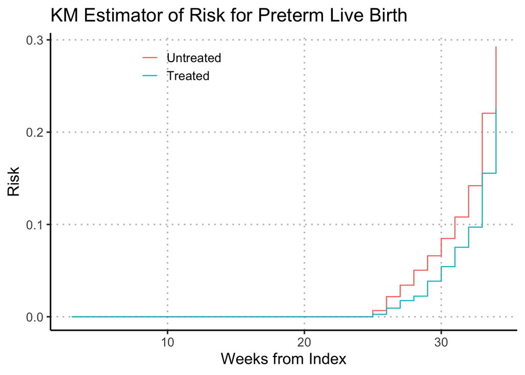

```r
## Create the preterm live birth outcome
trial2 <- trial %>%
  mutate(
    # Make an indicator that the patient was censored before we observed their outcome
    censor = ifelse(first_censoring_gw < preg_outcome_final_gw &
                      !is.na(first_censoring_gw),
                    1,
                    0),
    # Make an indicator for sga, incorporating censoring
    preterm_km = ifelse(preg_outcome_final_gw < 35 & censor == 0 &
                          preg_outcome_final == "livebirth", # Previously 37
                        1,
                        0),
    preterm_t = ifelse(preterm_km == 1, preg_outcome_final_gw,
                       ifelse(preterm_km == 0 & time >= 35, 34,
                              time))
    # preterm_t = ifelse(preterm_km == 1, preg_outcome_final_gw,
    #                ifelse(preg_outcome_final_gw < 35 & preg_outcome_final == "fetaldeath" &
    #                         censor == 0, preg_outcome_final_gw,
    #                       ifelse(preg_outcome_final_gw >= 35 & censor == 0, 34,
    #                              ifelse(censor == 1 & first_censoring_gw >= 35, 34,
    #                                     ifelse(censor == 1 & first_censoring_gw < 35,
    #                                            first_censoring_gw, NA)))))

    # preterm_t = case_when(
    #   preterm_km == 1 ~ preg_outcome_final_gw,
    #   preg_outcome_final_gw < 35 & preg_outcome_final == "fetaldeath" & censor == 0 ~ preg_outcome_final_gw,
    #   preg_outcome_final_gw >= 35 & censor == 0 ~ 35,
    #   censor == 1 & first_censoring_gw >= 35 ~ 35,
    #   censor == 1 & first_censoring_gw < 35 ~ first_censoring_gw
    # )

  )


  #     ifelse(preg_outcome_final_gw < 35 & censor == 0 &
  #                        preg_outcome_final == "livebirth", # Previously 37
  #                      preg_outcome_final_gw,
  #                      first_censoring_gw)
  #   ) %>%
  # # Now, account for the fact that follow-up should stop at 36 weeks.
  # mutate(
  #   # Reset outcome to what it should be at 36 weeks
  #   # This functionally shouldn't matter since preterm can only happen before 36 weeks
  #   preterm_km = ifelse(preterm_t >= 35,
  #                       0,
  #                       preterm_km),
  #   # Reset timing so that it ends at 36 weeks of follow-up
  #   preterm_t = ifelse(preterm_t >= 35,
  #                      35,
  #                      preterm_t)
  # )

## Run the KM analysis only considering the composite outcome.
wrisk <- km_estimator(trial2, "preterm_km","preterm_t")

riskplot <- km_plot(wrisk, "KM Estimator of Risk for Preterm Live Birth")

riskplot
```

```r
#ggsave(riskplot, file = "q13.png", width = 5, height = 5, units = "cm")
```

Output the risk ratio at the end of follow-up.

```r
km_rr <- km_rr_wCI(wrisk, 36)

# km_rr42
```

### AJ Estimator

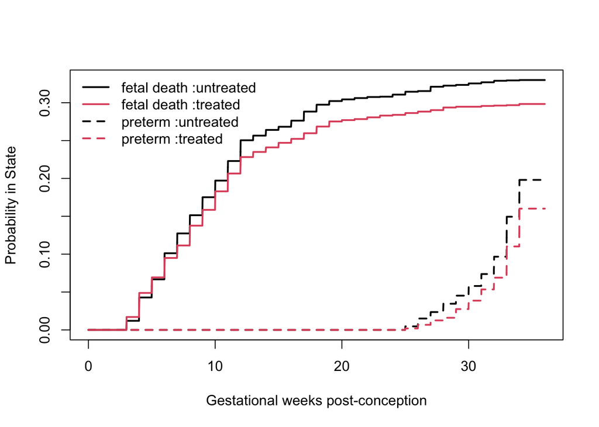

```r
## Make dataset the way that we want it
trial2 <- trial %>%
  mutate(
    # Make an indicator that the patient was censored before we observed their outcome
    censor = ifelse(first_censoring_gw < preg_outcome_final_gw & !is.na(first_censoring_gw),
                    1,
                    0),
    # Make a multi-level outcome
    preterm_multi = case_when(censor == 1 ~ 0,
                              censor == 0 & preg_outcome_final == "livebirth" &
                                preg_outcome_final_gw < 35 ~ 1,
                              censor == 0 & preg_outcome_final == "livebirth" &
                                preg_outcome_final_gw >= 35 ~ 2,
                              censor == 0 & preg_outcome_final == "fetaldeath" ~ 2),
    # Don't think we would calculate risks after 36 weeks since no longer at risk. Fetal
    # -- death is only competing event.
    # However,  do need to leave them in if not limiting all of the data to 36 weeks.
    # -- Need to clean up these data more.
    # Make a gestational week variable for the sga_multi variable
    preterm_multi_gw = ifelse(censor == 1,
                              first_censoring_gw,
                              preg_outcome_final_gw)
  ) %>%
  #Now, account for the fact that follow-up should stop at 36 weeks
  mutate(
    # Fix the outcomes to no event (i.e., censor) if the event timing is after 36 weeks
    preterm_multi = ifelse(preterm_multi_gw >= 35,
                           0, # i.e., treat as censoring event.
                          # 2, #i.e., safe from preterm birth, even if ultimatley end in fetal death
                           preterm_multi),
    # Cap the event timing at 36 weeks
    preterm_multi_gw = ifelse(preterm_multi_gw >= 35,
                              36, # i.e., if treat as censoring event
                              #36,
                              preterm_multi_gw)
  )


## Run the competing events analysis

# Make the AJ object

aj <- aj_estimator(trial2, "preterm_multi", "preterm_multi_gw")

# Calculate the RRs

aj_rrs_composite <- aj_rr(aj, 36)

# aj_rrs_composite

# Print the plot

aj_plot(aj_object = aj, outcome = "preterm", competing = "fetal death")
```

### Estimate the bias between KM and RR

```r
compare(km_rr, aj_rrs_composite)
```

| Estimator | Risk Among Untreated | Risk Among Treated | RR | RR 95% LCL | RR 95% UCL | RD | RD 95% LCL | RD 95% UCL |
| --- | --- | --- | --- | --- | --- | --- | --- | --- |
| Kaplan-Meier | 0.29 | 0.23 | 0.77 | 0.65 | 0.92 | -0.07 | -0.11 | -0.02 |
| Aalen-Johansen | 0.20 | 0.16 | 0.81 | 0.71 | 0.92 | -0.04 | -0.06 | -0.01 |
| Differences: KM-AJ | 0.09 | 0.07 | -0.05 | -0.08 | -0.01 | -0.03 | -0.05 | -0.01 |

### Estimate without censoring

```r
trial3 <- trial %>%
  mutate(preterm = ifelse(preg_outcome_final == "livebirth" & preg_outcome_final_gw < 35, 1, 0))

trial3 %>%
  group_by(trt) %>%
  summarize(risk = sum(preterm == 1) / n()) %>%
  pivot_wider(names_from = trt,
              values_from = c(risk),
              names_glue = "{.value}_{trt}") %>%
  rowwise() %>%
  mutate(rr = risk_1 / risk_0,
         rd = risk_1 - risk_0) %>%
  kable() %>%
  kable_classic()
```

| risk_0 | risk_1 | rr | rd |
| --- | --- | --- | --- |
| 0.199383 | 0.1502711 | 0.7536808 | -0.0491118 |